# Where the generation enters: generative vs. discriminative ancestry callers

Why RTIGER ignores the breeding generation while ELAI and nilHMM assume it — and why a gamma beats the exponential tract law

Author

Fausto Rodríguez-Zapata

Published

June 26, 2026

**Context.** Three ancestry callers in this project treat the breeding generation completely differently: **ELAI** assumes it, **nilHMM** (Holland) assumes it, **RTIGER** ignores it — and for RTIGER we instead postulate a simulation and retrofit a gamma to recover something like an effective generation. This note explains *why* that asymmetry exists, *why* a gamma is the right tract law where the exponential (ELAI’s) is not, and *where* each caller injects the generation. Conceptual glue between `docs/16-parameter-search-and-rigidity-mle.md` (why `r` is not an MLE), `fragment_size_cm_validation` (the gamma derivation), and `elai_admixture_mapping_plan` (ELAI’s model). Memory: `rigidity-not-mle`, `bc2s3-fragment-size-expectation`, `bzea-skim-bulked-bc2s2`, `optimize-R-overrigidifies-nil-sim`.

# 1. The split: generative vs. discriminative

The callers fall on two sides of a modelling choice.

- **Generative / model-based — ELAI, nilHMM.** They posit a *process* for how the genome came to look the way it does, **parametrized by the generation**. The generation is a structural input because the whole model is built around a specific history. You know the pedigree → you type the generation in.
- **Discriminative / segmentation — RTIGER.** It models **nothing** about how the tracts arose. It detects change-points in the marker sequence; its rigidity `r` is a **resolution** knob, not a generation. There is **no slot** for the generation. The only way to inject “this is a BC2S2 cross” is **externally**: simulate the generation-specific tract distribution and tune `r` to reproduce it.

That is the entire answer to “why does RTIGER ignore the generation”: **by design.** RTIGER was built to work on *any* cross without being told its structure (it even autotunes `r` from a generation-agnostic iid error model — which over-rigidifies, see `optimize-R-overrigidifies-nil-sim`). The price of that generality is that, for a *known* pedigree, it discards information that ELAI and nilHMM use directly — so you have to put the generation back in through calibration.

# 2. The generation is the same information — injected at different points

| Caller | Type | Takes the generation? | Where the generation enters | Tract-law assumption | What is fit vs. fixed |
| --- | --- | --- | --- | --- | --- |
| **ELAI** (Guan 2014) | generative | yes — `γ` (`-mg`) | the ancestry-switch **rate** in the transition (`γλ=100`) | **exponential** tracts, mean `1/γ` | fits `θ,α,β` by EM; `γ,N_e,μ,S,K` fixed/user-set |
| **nilHMM** (Holland) | generative | yes — via BC2S2 | **genotype-frequency prior** `f_1,f_2` (+ transition `r`) | per-marker freqs from the breeding scheme | fits emissions; `f_1,f_2` from generation, `r` calibrated |
| **RTIGER** | discriminative | **no** | **nowhere internally** — only via external `r`-calibration against a generation-specific simulated truth | none (generic change-point) | `r` is a resolution knob set by KS-vs-sim; emissions EM-fit |

The crucial reading of this table: **generation is the same fact in all three callers; they just inject it in different places.** ELAI puts it in the tract-rate prior, nilHMM in the frequency prior, RTIGER nowhere — so for RTIGER it re-enters as the *calibration target*. The “convoluted” simulate→gamma→calibrate-`r` workflow is **the cost of RTIGER’s agnosticism, not an intrinsic requirement of the problem.**

# 3. Two parameters that get conflated: the generative `λ` vs. the caller knob `r`

The frustration “I retrofit a gamma to find a parameter that is approximately `g_eff`” comes from collapsing two distinct things:

- **The generative parameter** is the gamma’s **rate `λ`** (∝ generation): it *is* the tract-length law of the population. This is what the simulation gives you and what `g_eff` refers to.
- **The caller knob** is RTIGER’s **`r`**: a *resolution* setting you tune so the caller’s output *reproduces* that law. `r` is **not** the generation, and it cannot be MLE’d — it is a regularization hyperparameter, and the caller’s own likelihood runs monotone toward minimum rigidity (`docs/16`, `rigidity-not-mle`).

ELAI and nilHMM **fuse** these into one generation input (the law parameter *is* the model knob). RTIGER **splits** them: you establish the law from the simulation (`λ`), then separately tune the resolution (`r`) to match it. That split is exactly why the RTIGER route feels like extra machinery — you are doing two jobs the generative callers do in one.

# 4. Why a gamma, not the exponential (ELAI’s tract law)

The exponential **is** the gamma with shape `k=1`. So the question is only: *let the shape float, or pin it at 1?*

- **The exponential is correct in ELAI’s regime.** Old, single-pulse, random-mating admixture → over thousands of generations the junction process superposes to Poisson and, on one lineage, the tract length is **memoryless → exponential**, mean `1/γ`. One parameter; `CV=1`, `skew=2` are forced.
- **A few-generation designed pedigree breaks those assumptions** → shape `k` just above 1 (≈1.15): crossover **interference** (spacing more regular than memoryless), the **union of the two homologs** (a tract is donor if *either* chromosome is — merges/absorbs the shortest), and a **finite, small number of meioses** (the superposition-to-Poisson limit is not reached). The exponential **cannot** represent `k≠1`; the gamma’s second parameter matches the **shape** (the mode, the short-tract deficit, the tail), not just the mean. The derivation (`fragment_size_cm_validation`) brackets it **Exp(5) ≤ · ≤ Gamma(2)** and the simulation lands at **Gamma(k≈1.15, λ≈4.72/Morgan)**, KS `D≈0.028`, with both brackets rejected.

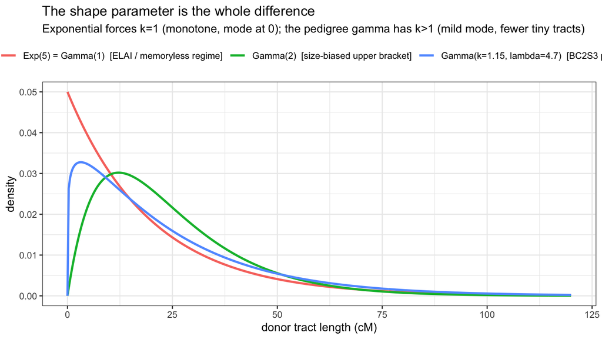

```r
library(ggplot2)
xs  <- seq(0, 120, length.out = 400)            # donor tract length, cM
k   <- 1.15; lam <- 4.72                         # fitted BC2S3 gamma (per Morgan)
m_cM <- k / lam * 100                            # its mean in cM
df <- rbind(
  data.frame(cm = xs, d = dexp(xs/100, rate = 5)/100,
             law = "Exp(5) = Gamma(1)  [ELAI / memoryless regime]"),
  data.frame(cm = xs, d = dgamma(xs/100, shape = k, rate = lam)/100,
             law = sprintf("Gamma(k=%.2f, lambda=%.1f)  [BC2S3 pedigree]", k, lam)),
  data.frame(cm = xs, d = dgamma(xs/100, shape = 2, rate = 2/(m_cM/100))/100,
             law = "Gamma(2)  [size-biased upper bracket]"))
ggplot(df, aes(cm, d, colour = law)) +
  geom_line(linewidth = 1) +
  labs(x = "donor tract length (cM)", y = "density", colour = NULL,
       title = "The shape parameter is the whole difference",
       subtitle = "Exponential forces k=1 (monotone, mode at 0); the pedigree gamma has k>1 (mild mode, fewer tiny tracts)") +
  theme_bw() + theme(legend.position = "top")
```

**But keep the magnitude honest.** In cM the gap is modest (`k≈1.15` is close to 1), so as a *model’s internal prior* the exponential is a fine approximation — HMMs are robust to the exact prior shape. The gamma’s correctness matters where the distribution is used **quantitatively**: as the **Null / expectation** in size plots and as a **calibration target**, and especially in **Mb**, where the cM→Mb pushforward (recombination-rate heterogeneity) makes the law **LogNormal** and the naive scaled exponential is badly wrong (KS `0.22`; `bc2s3-fragment-size-expectation`).

# 5. Practical consequence / the call

- **If you want the generation handled directly** — exactly as ELAI and Holland do — **do not use the RTIGER route.** Use **nilHMM**: it is already pedigree-aware and ingests the BC2S2 prior. The simulate→gamma→calibrate-`r` dance is *specific to RTIGER*, a generation-agnostic tool. For a *known* pedigree, a generative model that takes the generation is the natural fit.
- **The simulation + gamma is still worth keeping regardless of caller** — as the quantitative **Null** for size plots and as the **cross-caller calibration target** — because it gives the correctly-shaped (pedigree) reference that neither ELAI’s exponential nor an assumed-`g` prior provides.
- **Do not try to MLE `r` or read it as `g_eff`.** The generative parameter is the gamma’s `λ` (from the sim); `r` is a resolution knob tuned to it (`docs/16`).

**One-line picture:** generation is one fact; ELAI puts it in the *tract-rate prior* (exponential), nilHMM in the *frequency prior* (BC2S2), RTIGER *nowhere* (so you calibrate `r` against a simulated truth). The gamma beats the exponential as a *reference law* because a few-generation pedigree is not memoryless — and that matters most for the Null and in Mb, less for a caller’s internal prior.